# Introduction to R - Week 2

M.C. Hoogendijk

2017-08-07

## Course

### Goals of the Course

- Learn Base R & RStudio
- Provide a solid foundation from which to succeed for RMSC future courses

### Overview

Training Consists of 3 Lectures / Sessions, each 3 hours

- Session 1: Overall Introduction to R Syntax & Environment, Data Import & Data Cleaning.
- Session 2: Data Manipulation (apply functions & loops) & Matrix algebra. OO Programming.
- Session 3: Data Visualization & Showcase Reproducible Research. Introduce the “Hadleyverse”. Future learning of R.

As we move through the course the examples will be more extensive and have all aspects required for working with Data

### Set-Up

Typical work flow in R

- Data Importing & Exporting
- Data Cleaning
- Data Manipulation
- Data Visualization (basic, first impression)
- Data Analysis
- Data Visualization (advanced, capture final conclusion)
- Data Summary / Reports

### Overview of Session 1

- Introduction to RStudio
- How to get Help & Documentation
- Data Types
- Data Structures
- Reserved Words
- Basic Mathematical & Statistical Functions
- Cleaning & Subsetting Data
- Importing & Exporting Data

### Overview of Session 2

- Matrix Algebra
- OO Programming. S3 & S4.
- Apply Family
- xts
- packages

## Quick Review Session 1

- Data Types (Locigal, Integer, Double, Character, Complex), where factor is a class of type integer
- Data Structures (NULL, Vector, Matrix, Array, Data.frame, List)
- Mathamatical & Statistical functions (sin, cos, tan, sd, var, cov)
- Built in Vectors (LETTERS, letters, month.name)
- Useful Functions (rep, replicate, seq, sample)
- Information Functions (type, class, str, head, tail, summary, ncol, nrow, dim, length, names)
- Importing & Exporting datasets
- Built in datasets ( data() )
- Subsetting of datasets
- Random Numbers / Probability Distributions
- Base plotting
- R & RStudio Environment

## Practice Iris Dataset

The iris dataset in R is one of the most well known datasets within the R programming world.

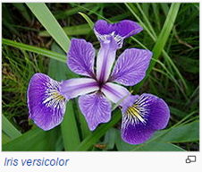

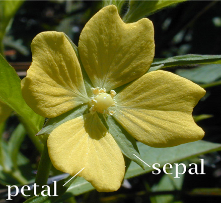

Access to the dataset:

```r
data(iris)
```

Quick look at the first 6 obeservations

```r
head(iris)
```

```
##   Sepal.Length Sepal.Width Petal.Length Petal.Width Species
## 1          5.1         3.5          1.4         0.2  setosa
## 2          4.9         3.0          1.4         0.2  setosa
## 3          4.7         3.2          1.3         0.2  setosa
## 4          4.6         3.1          1.5         0.2  setosa
## 5          5.0         3.6          1.4         0.2  setosa
## 6          5.4         3.9          1.7         0.4  setosa
```

Quick look at the last 6 observations

```r
tail(iris)
```

```
##     Sepal.Length Sepal.Width Petal.Length Petal.Width   Species
## 145          6.7         3.3          5.7         2.5 virginica
## 146          6.7         3.0          5.2         2.3 virginica
## 147          6.3         2.5          5.0         1.9 virginica
## 148          6.5         3.0          5.2         2.0 virginica
## 149          6.2         3.4          5.4         2.3 virginica
## 150          5.9         3.0          5.1         1.8 virginica
```

structure of the data

```r
str(iris)
```

```
## 'data.frame':    150 obs. of  5 variables:
##  $ Sepal.Length: num  5.1 4.9 4.7 4.6 5 5.4 4.6 5 4.4 4.9 ...
##  $ Sepal.Width : num  3.5 3 3.2 3.1 3.6 3.9 3.4 3.4 2.9 3.1 ...
##  $ Petal.Length: num  1.4 1.4 1.3 1.5 1.4 1.7 1.4 1.5 1.4 1.5 ...
##  $ Petal.Width : num  0.2 0.2 0.2 0.2 0.2 0.4 0.3 0.2 0.2 0.1 ...
##  $ Species     : Factor w/ 3 levels "setosa","versicolor",..: 1 1 1 1 1 1 1 1 1 1 ...
```

summary overview of the data

```r
summary(iris)
```

```
##   Sepal.Length    Sepal.Width     Petal.Length    Petal.Width          Species
##  Min.   :4.300   Min.   :2.000   Min.   :1.000   Min.   :0.100   setosa    :50
##  1st Qu.:5.100   1st Qu.:2.800   1st Qu.:1.600   1st Qu.:0.300   versicolor:50
##  Median :5.800   Median :3.000   Median :4.350   Median :1.300   virginica :50
##  Mean   :5.843   Mean   :3.057   Mean   :3.758   Mean   :1.199
##  3rd Qu.:6.400   3rd Qu.:3.300   3rd Qu.:5.100   3rd Qu.:1.800
##  Max.   :7.900   Max.   :4.400   Max.   :6.900   Max.   :2.500
```

```r
typeof(iris)
```

```
## [1] "list"
```

```r
class(iris)
```

```
## [1] "data.frame"
```

```r
dim(iris)
```

```
## [1] 150   5
```

names() is useful for data.frames, matrices, vectors and lists

```r
names(iris)
```

```
## [1] "Sepal.Length" "Sepal.Width"  "Petal.Length" "Petal.Width"  "Species"
```

colnames() works specifically for data.frames and matrices

```r
colnames(iris)
```

```
## [1] "Sepal.Length" "Sepal.Width"  "Petal.Length" "Petal.Width"  "Species"
```

subsetting data: Looking at one specific column

```r
head(iris["Petal.Width"])
```

```
##   Petal.Width
## 1         0.2
## 2         0.2
## 3         0.2
## 4         0.2
## 5         0.2
## 6         0.4
```

First 10 rows of two columns

```r
iris[1:10,c("Petal.Length","Petal.Width")]
```

```
##    Petal.Length Petal.Width
## 1           1.4         0.2
## 2           1.4         0.2
## 3           1.3         0.2
## 4           1.5         0.2
## 5           1.4         0.2
## 6           1.7         0.4
## 7           1.4         0.3
## 8           1.5         0.2
## 9           1.4         0.2
## 10          1.5         0.1
```

Finding those rows where the Sepal.Length is larger than the average Sepal.Length

```r
head(iris[iris$Sepal.Length > mean(iris$Sepal.Length),],10)
```

```
##    Sepal.Length Sepal.Width Petal.Length Petal.Width    Species
## 51          7.0         3.2          4.7         1.4 versicolor
## 52          6.4         3.2          4.5         1.5 versicolor
## 53          6.9         3.1          4.9         1.5 versicolor
## 55          6.5         2.8          4.6         1.5 versicolor
## 57          6.3         3.3          4.7         1.6 versicolor
## 59          6.6         2.9          4.6         1.3 versicolor
## 62          5.9         3.0          4.2         1.5 versicolor
## 63          6.0         2.2          4.0         1.0 versicolor
## 64          6.1         2.9          4.7         1.4 versicolor
## 66          6.7         3.1          4.4         1.4 versicolor
```

The question now remains how to get more information on the data for each species. And this is were the apply family within R comes into play. Before we move here, we first cover matrix algebra.

## Matrix Algebra

Below an overview of the different functions available for matrix algebra

```r
matrix()
t()
diag()
crossprod()
solve()
det()
eigen()
```

```r
set.seed(12345)
matrix_A <- matrix(sample(1:64,replace=TRUE),4,4)
matrix_B <- matrix(c(2,3,4,5,2,6,7,8),4,2)
```

Transpose

```r
 t(matrix_A)
```

```
##      [,1] [,2] [,3] [,4]
## [1,]   47   57   49   57
## [2,]   30   11   21   33
## [3,]   47   64    3   10
## [4,]   48    1   26   30
```

Matrix Multiplication (inner product)

```r
matrix_A %*% matrix_B
```

```
##      [,1] [,2]
## [1,]  612  987
## [2,]  408  636
## [3,]  303  453
## [4,]  403  622
```

Matrix Multiplication (outer product)

```r
matrix_A %o% matrix_B
```

```
## , , 1, 1
##
##      [,1] [,2] [,3] [,4]
## [1,]   94   60   94   96
## [2,]  114   22  128    2
## [3,]   98   42    6   52
## [4,]  114   66   20   60
##
## , , 2, 1
##
##      [,1] [,2] [,3] [,4]
## [1,]  141   90  141  144
## [2,]  171   33  192    3
## [3,]  147   63    9   78
## [4,]  171   99   30   90
##
## , , 3, 1
##
##      [,1] [,2] [,3] [,4]
## [1,]  188  120  188  192
## [2,]  228   44  256    4
## [3,]  196   84   12  104
## [4,]  228  132   40  120
##
## , , 4, 1
##
##      [,1] [,2] [,3] [,4]
## [1,]  235  150  235  240
## [2,]  285   55  320    5
## [3,]  245  105   15  130
## [4,]  285  165   50  150
##
## , , 1, 2
##
##      [,1] [,2] [,3] [,4]
## [1,]   94   60   94   96
## [2,]  114   22  128    2
## [3,]   98   42    6   52
## [4,]  114   66   20   60
##
```

[output cut: 8 more lines]

```
## , , 3, 2
##
##      [,1] [,2] [,3] [,4]
## [1,]  329  210  329  336
## [2,]  399   77  448    7
## [3,]  343  147   21  182
## [4,]  399  231   70  210
##
## , , 4, 2
##
##      [,1] [,2] [,3] [,4]
## [1,]  376  240  376  384
## [2,]  456   88  512    8
## [3,]  392  168   24  208
## [4,]  456  264   80  240
```

Matrix Crossproduct

```r
crossprod(matrix_A, matrix_B)
```

```
##      [,1] [,2]
## [1,]  746 1235
## [2,]  342  537
## [3,]  348  579
## [4,]  353  524
```

Matrix Crossproduct

```r
all.equal(crossprod(matrix_A, matrix_B), t(matrix_A) %*% matrix_B)
```

```
## [1] TRUE
```

Inverse:

```r
solve(matrix_A)
```

```
##              [,1]         [,2]        [,3]          [,4]
## [1,] -0.011167569  0.009523718  0.04590860 -0.0222368033
## [2,] -0.007486527 -0.006862577 -0.11805878  0.1145248018
## [3,]  0.010829053  0.008531664 -0.02137354  0.0009128637
## [4,]  0.025843877 -0.013390118  0.04976282 -0.0506983103
```

```r
round(solve(matrix_A) %*% matrix_A,10)
```

```
##      [,1] [,2] [,3] [,4]
## [1,]    1    0    0    0
## [2,]    0    1    0    0
## [3,]    0    0    1    0
## [4,]    0    0    0    1
```

Diagonal:

```r
diag(matrix_A)
```

```
## [1] 47 11  3 30
```

Determinant:

```r
det(matrix_A)
```

```
## [1] -1149131
```

Eigenvalues:

```r
eigen(matrix_A)
```

```
## $values
## [1] 138.98634+ 0.00000i -30.49853+ 0.00000i  -8.74390+13.95125i  -8.74390-13.95125i
##
## $vectors
##              [,1]           [,2]                    [,3]                    [,4]
## [1,] 0.6134499+0i -0.66721375+0i  0.25373739-0.13040864i  0.25373739+0.13040864i
## [2,] 0.4718271+0i  0.06382507+0i -0.87042954+0.00000000i -0.87042954+0.00000000i
## [3,] 0.3893962+0i  0.54498131+0i  0.03864431-0.07831507i  0.03864431+0.07831507i
## [4,] 0.4994287+0i  0.50373360+0i  0.24940946+0.30188016i  0.24940946-0.30188016i
```

Solve for Upper or Lower Triangular System

```r
backsolve()
forwardsolve()
chol()  # for choleski factorization
```

## Object Oriented Programming (OOP)

### OOP in R

“Central to any object-oriented language are the concepts of class and of methods. A class is a definition of an object. Typically a class contains several slots that are used to hold class specific information. An object in the language must be an instance of some class. Programming is based on objects or instances of classes.”

“Computations are carried out via methods. Methods are basically functions that are specialized to carry out specific calculations on objects, usually of a specific class. This is what makes the language object oriented. In R, generic functions are used to determine the appropriate method. The generic function is responsible for determining the class of its argument(s) and uses that information to select the appropriate method.”

**Source: R Language Definition, version 3.2.1, R Core Team**

List of generic functions()

```r
print()
summary()
plot()
```

### OOP Systems in R

- R has three object oriented systems (plus the base types)
- Central to any OO system are the concepts of class and method
- A class defines the behavior of objects by describing their attributes and their relationship to other classes
- The class is also used when selecting methods, functions that behave differently depending on the class of their input

R’s three OO Systems

- S3
- S4
- RC

**Source: Advanced R, Hadley Wickham, CRC Press**

### S Languange

S3 & S4 are based on the Evolution of the S Language

Evolution of S Languange, 4 major milestones

1. Object types, a set of internal types defined in the C implementation, and originally called modes in S;
2. Vector structures, defined by the concept of vectors (indexable objects) with added structure defined by attributes;
3. S3 classes, that is, objects with class attributes and corresponding one-argument method dispatch, but without class definitions;
4. Formal classes with class definitions, and corresponding generic functions and general methods, usually called S4 classes and methods in R.

Source **“Software for Data Analysis; Programming with R” by John M. Chambers**

**S3 is R’s first and simplist OO System**

### S3

Most functions in Base R are s3. Examples:

```r
?plot()
```

To get insight into the available method for each class (Needs to be a geneirc function)

```r
methods(plot)
```

The functions print() and summary() are two other well known generic functions.

Then to see the function code based on the class we can use:

```r
getS3method(plot)
```

A data.frame is an example of a S3 Object

The only way to check, within Base R, if an object is S3 is if the below code returns TRUE

```r
is.object() & !isS4
```

Example S3 object

```r
df <- data.frame(A = 1:20,
                 B = runif(20) + (1:20))
is.object(df) & !isS4(df)
```

```
## [1] TRUE
```

### S4

For S4, we can easily check if they are S4 via isS4()

RStudio also captures this by stating the object as “Formal Class”

When we look at the structure within RStudio via the Environment tab, we see @ slots.

Which brings us to the most important aspect that requires understanding -> extracting information of s4 Objects:

@ or slot() can be used to extract a particular part of the object, similar to $ and [[ for S3 objects

Take the following example:

```r
library("Matrix")
M2 <- toeplitz(as(c(1,.5, rep(0,12), -.1), "sparseVector"))
c2 <- chol(M2)
```

```r
isS4(M2)
```

```
## [1] TRUE
```

```r
isS4(c2)
```

```
## [1] TRUE
```

Continuing the example:

```r
slot(c2,"x")
```

```
##  [1]  1.00000000  0.50000000  0.86602540  0.57735027  0.81649658  0.61237244  0.79056942  0.63245553
##  [9]  0.77459667  0.64549722  0.76376262  0.65465367  0.75592895  0.66143783  0.75000000  0.66666667
## [17]  0.74535599  0.67082039  0.74161985  0.67419986  0.73854895  0.67700320  0.73598007  0.67936622
## [25]  0.73379939  0.68138514  0.73192505 -0.10000000  0.05773503 -0.04082483  0.03162278 -0.02581989
## [33]  0.02182179 -0.01889822  0.01666667 -0.01490712  0.01348400 -0.01230915  0.01132277 -0.01048285
## [41]  0.69288905  0.70804896
```

```r
c2@x
```

```
##  [1]  1.00000000  0.50000000  0.86602540  0.57735027  0.81649658  0.61237244  0.79056942  0.63245553
##  [9]  0.77459667  0.64549722  0.76376262  0.65465367  0.75592895  0.66143783  0.75000000  0.66666667
## [17]  0.74535599  0.67082039  0.74161985  0.67419986  0.73854895  0.67700320  0.73598007  0.67936622
## [25]  0.73379939  0.68138514  0.73192505 -0.10000000  0.05773503 -0.04082483  0.03162278 -0.02581989
## [33]  0.02182179 -0.01889822  0.01666667 -0.01490712  0.01348400 -0.01230915  0.01132277 -0.01048285
## [41]  0.69288905  0.70804896
```

For more information on S3 & S4 within R you can use the below:

```r
?Methods
```

```r
?S3Methods
```

### Reference Materials

For clear and thorough understanding of S3 & S4 best to read:  
**“Software for Data Analysis; Programming with R” by John M. Chambers**

For a short but powerful description:

**“Advanced R” by Hadley Wickham**

## Apply Family

### The Family of Apply Functions

The apply family of functions are one of the great powers of R. In most cases they are a replacement of using loops in R. A solid understanding of the apply functions is highly recommended.

Below a short summary will be given on the main apply functions.

List of Apply functions:

```r
apply()
lapply()
sapply()
tapply()
mapply()
eapply()
rapply()
vapply()
```

### Dummy Data Set

Here we create a Dummy Data Set:

First step is the dates vector:

```r
A <- Sys.Date()+1:500
```

Then take out all days that are not weekdays from the vector

```r
week <- c("Monday","Tuesday","Wednesday","Thursday","Friday")
MD <- A[weekdays(A) %in% week]
```

Daily Vol numbers:

```r
Vol_HS <- 0.2/sqrt(252)
Vol_CSI <- 0.4/sqrt(252)
Vol_STI <- 0.12/sqrt(252)
Vol_N225 <- 0.25/sqrt(252)
```

Final Data frame

```r
set.seed(12345)
df <- data.frame(Date = MD,
                 HS   = rnorm(length(MD),sd=Vol_HS),
                 CSI  = rnorm(length(MD),sd=Vol_CSI),
                 STI  = rnorm(length(MD),sd=Vol_STI),
                 N225 = rnorm(length(MD),sd=Vol_N225))
```

Quick look at the data:

```r
head(df)
```

```
##         Date           HS          CSI          STI          N225
## 1 2017-08-08  0.007376970  0.011919696 -0.008792884  0.0079384022
## 2 2017-08-09  0.008938432 -0.023160522  0.012706363 -0.0005292137
## 3 2017-08-10 -0.001377092 -0.009469860  0.009200566  0.0168160868
## 4 2017-08-11 -0.005713527 -0.045679117 -0.000207418 -0.0170771331
## 5 2017-08-14  0.007633464  0.007272042 -0.002203878  0.0089098120
## 6 2017-08-15 -0.022904092 -0.004778040  0.007352375 -0.0043480216
```

```r
summary(df)
```

```
##       Date                  HS                 CSI                  STI
##  Min.   :2017-08-08   Min.   :-0.032528   Min.   :-0.0700072   Min.   :-0.0193522
##  1st Qu.:2017-12-11   1st Qu.:-0.007357   1st Qu.:-0.0140061   1st Qu.:-0.0053929
##  Median :2018-04-14   Median : 0.001687   Median : 0.0008150   Median :-0.0005731
##  Mean   :2018-04-14   Mean   : 0.001354   Mean   : 0.0009209   Mean   :-0.0004795
##  3rd Qu.:2018-08-16   3rd Qu.: 0.009789   3rd Qu.: 0.0169068   3rd Qu.: 0.0047169
##  Max.   :2018-12-20   Max.   : 0.034614   Max.   : 0.0839266   Max.   : 0.0233861
##       N225
##  Min.   :-0.0525162
##  1st Qu.:-0.0108047
##  Median : 0.0003205
##  Mean   :-0.0002047
##  3rd Qu.: 0.0117943
##  Max.   : 0.0517972
```

The apply() function can be used across rows and columns

For Columns:

```r
apply(df[,2:5],2,sd)
```

```
##          HS         CSI         STI        N225
## 0.012907001 0.025039073 0.007350513 0.015955093
```

```r
apply(df[,2:5],2,sd)*sqrt(252)
```

```
##        HS       CSI       STI      N225
## 0.2048923 0.3974830 0.1166858 0.2532792
```

```r
apply(df[,2:5],2,mean)
```

```
##            HS           CSI           STI          N225
##  0.0013536368  0.0009209080 -0.0004794660 -0.0002046718
```

For Rows

```r
head(apply(df[,2:5],1,mean))
```

```
## [1]  0.0046105458 -0.0005112353  0.0037924251 -0.0171692989  0.0054028601 -0.0061694446
```

```r
weights <- c(0.2,0.3,0.3,0.2)
sum(weights)
```

```
## [1] 1
```

```r
head(apply(df[,2:5],1,function(x) sum(weights * x)))
```

```
## [1]  0.004001118 -0.001454404  0.003007011 -0.018324093  0.004829105 -0.004678122
```

### tapply()

```r
df$Year <- factor(format(df$Date,'%Y'))
tapply(df[,"HS"],df$Year,sd)
```

```
##       2017       2018
## 0.01401209 0.01241014
```

As tapply only works on vectors, we need to use one more apply function to get the results for all columns

```r
apply(df[,2:5],2,function(x) tapply(x,df$Year,sd))
```

```
##              HS        CSI         STI       N225
## 2017 0.01401209 0.02288498 0.007257507 0.01605129
## 2018 0.01241014 0.02584105 0.007239914 0.01591130
```

### lapply()

A simple example:

```r
A_list <- list(A = 1:10,
               B = 11:20,
               C = 21:30,
               D = 31:40)
lapply(A_list,mean)
```

```
## $A
## [1] 5.5
##
## $B
## [1] 15.5
##
## $C
## [1] 25.5
##
## $D
## [1] 35.5
```

Note the outcome is a list with the same length as the input

If the outcome can be simplified then using sapply produces a desirable outcome

```r
sapply(A_list,mean)
```

```
##    A    B    C    D
##  5.5 15.5 25.5 35.5
```

Note that is important to understand the benefits of Data Frames and lists

```r
df_l <- list(HS   = df[,c(1,2)],
             CSI  = df[,c(1,3)],
             STI  = df[,c(1,4)],
             N225 = df[,c(1,5)])
sapply(df_l, function(x) sd(x[,-1])*sqrt(252))
```

```
##        HS       CSI       STI      N225
## 0.2048923 0.3974830 0.1166858 0.2532792
```

```r
all.equal(apply(df[,2:5],2,sd), sapply(df_l,function(x) sd(x[,-1])))
```

```
## [1] TRUE
```

## Apply Family in Action

### Iris dataset

```r
apply(iris[1:4], 2, class)
```

```
## Sepal.Length  Sepal.Width Petal.Length  Petal.Width
##    "numeric"    "numeric"    "numeric"    "numeric"
```

```r
sapply(iris, class)
```

```
## Sepal.Length  Sepal.Width Petal.Length  Petal.Width      Species
##    "numeric"    "numeric"    "numeric"    "numeric"     "factor"
```

```r
tapply(iris[,"Petal.Width"],iris[,"Species"],mean)
```

```
##     setosa versicolor  virginica
##      0.246      1.326      2.026
```

```r
apply(iris[,1:4],2, function(x) tapply(x,iris[,"Species"],mean))
```

```
##            Sepal.Length Sepal.Width Petal.Length Petal.Width
## setosa            5.006       3.428        1.462       0.246
## versicolor        5.936       2.770        4.260       1.326
## virginica         6.588       2.974        5.552       2.026
```

### Government Bond Yields

In the below example US Government Rates are downloaded from FRED website using lapply()

```r
library(xts)
library(quantmod)
```

```r
rate_symbols <- c("DGS1","DGS2","DGS3","DGS5","DGS7","DGS10","DGS20","DGS30")
Rates <- lapply(rate_symbols, function(x) getSymbols(x, src='FRED', auto.assign = FALSE))
```

Combining the data into one xts object:

```r
Rates <- do.call(cbind.xts,Rates)
```

```r
tail(Rates)
```

```
##            DGS1 DGS2 DGS3 DGS5 DGS7 DGS10 DGS20 DGS30
## 2017-07-27 1.22 1.36 1.52 1.84 2.12  2.32  2.68  2.93
## 2017-07-28 1.22 1.34 1.51 1.83 2.10  2.30  2.65  2.89
## 2017-07-31 1.23 1.34 1.51 1.84 2.11  2.30  2.66  2.89
## 2017-08-01 1.22 1.34 1.50 1.80 2.07  2.26  2.61  2.86
## 2017-08-02 1.24 1.36 1.52 1.82 2.08  2.27  2.60  2.85
## 2017-08-03 1.22 1.34 1.49 1.79 2.05  2.24  2.56  2.81
```

Data Manipulation

```r
library(reshape2)
Rates <- data.frame(Date = index(Rates), coredata(Rates), stringsAsFactors = FALSE)
Rates <- melt(Rates,id.vars = "Date")
Rates$Year <- format(Rates$Date, '%Y')
```

```r
tail(Rates)
```

```
##              Date variable value Year
## 116019 2017-07-27    DGS30  2.93 2017
## 116020 2017-07-28    DGS30  2.89 2017
## 116021 2017-07-31    DGS30  2.89 2017
## 116022 2017-08-01    DGS30  2.86 2017
## 116023 2017-08-02    DGS30  2.85 2017
## 116024 2017-08-03    DGS30  2.81 2017
```

Plotting the data

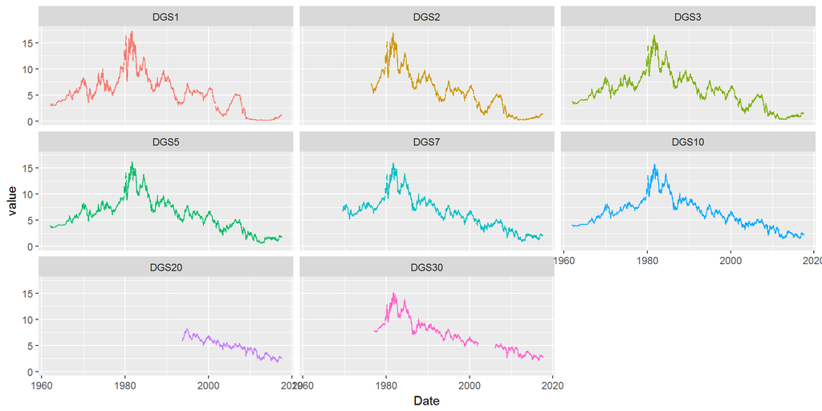

```r
library(ggplot2)
library(ggthemes)
ggplot(Rates, aes(x=Date,y=value)) + geom_line(aes(colour = variable)) + facet_wrap(~variable) + theme(legend.position = "none")
```

### ETF’s

Here certain ETF’s are downloaded from yahoo finance. From this data the monthly returns will be calculated.

```r
Tickers     <- c("IWM","AGG","TLT","TIP","ILF","HYG","EMB","GSG","ICF","IXC")
```

```r
ETF_Data   <- sapply(Tickers,
                     function(x) tryCatch(getSymbols(x, auto.assign=FALSE),
                                          error = function(e){print(paste(x,'not found'));NA}),
                     simplify = FALSE,
                     USE.NAMES = TRUE)
```

Quick look at the data

```r
tail(ETF_Data$IWM)
```

```
##            IWM.Open IWM.High IWM.Low IWM.Close IWM.Volume IWM.Adjusted
## 2017-07-28   142.02   142.36  141.47    141.96   19933300       141.96
## 2017-07-31   142.22   142.38  140.97    141.51   16417700       141.51
## 2017-08-01   142.17   142.20  140.97    141.78   19835900       141.78
## 2017-08-02   141.59   141.82  139.73    140.23   19934300       140.23
## 2017-08-03   140.44   140.54  139.16    139.53   19624900       139.53
## 2017-08-04   139.91   140.32  139.49    140.21   15625500       140.21
```

The last close based on adjusted price

```r
sapply(ETF_Data, function(x) xts::last(Ad(x)))
```

```
##    IWM    AGG    TLT    TIP    ILF    HYG    EMB    GSG    ICF    IXC
## 140.21 109.68 124.93 113.63  33.32  88.50 115.23  14.44 101.78  32.10
```

Here the monthly returns are calculated for all ETF’s

```r
ETF_MR <- lapply(ETF_Data, function(x) monthlyReturn(Ad(x)))
```

```r
tail(ETF_MR$IWM)
```

```
##            monthly.returns
## 2017-03-31     0.000260345
## 2017-04-28     0.011492638
## 2017-05-31    -0.019703697
## 2017-06-30     0.033744140
## 2017-07-31     0.008524502
## 2017-08-04    -0.009186545
```

The monthly performance for this August:

```r
sapply(ETF_MR, function(x) xts::last(x))
```

```
##           IWM           AGG           TLT           TIP           ILF           HYG           EMB
## -0.0091865454  0.0023761836  0.0093640349  0.0016483697  0.0103092784 -0.0004744302  0.0036932129
##           GSG           ICF           IXC
## -0.0116358658 -0.0034269853 -0.0012445862
```

The monthly performance for July 2017:

```r
sapply(ETF_MR, function(x) x['201707'])
```

```
##          IWM          AGG          TLT          TIP          ILF          HYG          EMB
##  0.008524502  0.003339961 -0.006583233  0.004613840  0.089167732  0.010191764  0.011789267
##          GSG          ICF          IXC
##  0.042082739  0.009988073  0.035438079
```

## References

- R in a Nutshell, Joseph Adler, O’Reilly
- Hands-On Programming with R, Garrett Grolemund, O’Reilly
- Advanced R, Hadley Wickham, CRC Press
- The R Inferno, Patrick Burns
- The R Graphics Cookbook, Winston Chang, O’Reilly
- GGPLOT2: Elegant Graphics for Data Analysis, Hadley Wickham, Springer